# Lab 8

**1.Write a function to convert a vector of raw-scores into z-scores. The function should have inputs for the vector, the mean and sd of the normal distribution, and should return a vector of zscores. (1 point). Also, demonstrate that the function works correctly (1 point). How you make the demonstration is up to you.**

##We define our variables we want to use within our function (inputs)

```r
rawscores <- "raw score"
mu <- "mean"
sigma <- "std deviation of the normal distribution"
```

##We then use these in a function which returns a Z Score

```r
rawscores <- c(1,2,3,4,5,6)
mu <- mean(rawscores)
sigma <- sd(rawscores)

rawto_zscores <- function(rawscores,mu,sigma){
z_scorecalculated <-(rawscores-mu)/sigma
return(z_scorecalculated)
}
rawto_zscores(rawscores,mu,sigma)
```

```
## [1] -1.3363062 -0.8017837 -0.2672612  0.2672612  0.8017837  1.3363062
```

##demonstrate

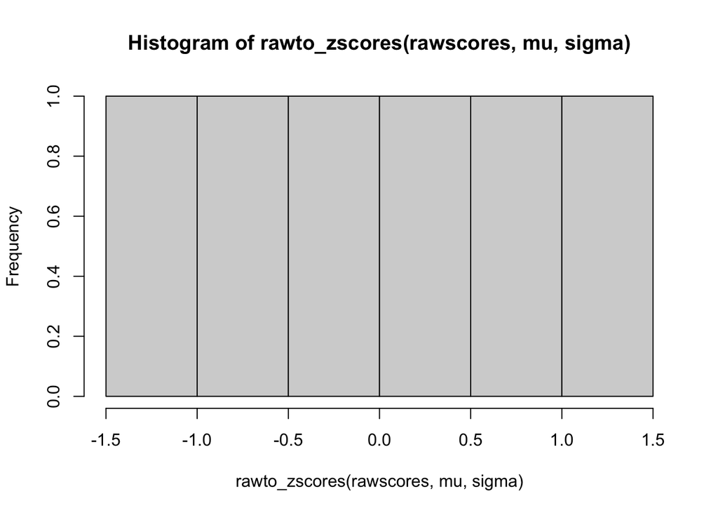

```r
hist(rawto_zscores(rawscores,mu,sigma))
```

Looks right when compared to our vector entry (flat distribution of ascending values)

*Self-Assessment: 100/100*

**Advanced: Have an option so that the function will convert the raw scores to zscores in one of two ways: 1) using user provided mean and standard deviation 2) using the calculated mean and standard deviation from the raw scores**

##What was the mean and SD?

```r
mu
```

```
## [1] 3.5
```

```r
sigma
```

```
## [1] 1.870829
```

##Use “known” values instead to show advanced #1

```r
rawto_zscores(rawscores,3.5,1.870829)
```

```
## [1] -1.3363060 -0.8017836 -0.2672612  0.2672612  0.8017836  1.3363060
```

##Now ‘soup up’ the raw-to-z so that you only have to specify vector for advanced #2

```r
rawscores <- c(1,2,3,4,5,6)
mu <- mean(rawscores)
sigma <- sd(rawscores)

rawto_zscoresSouped <- function(rawscores){
z_scorecalculated <-(rawscores-mean(rawscores))/sd(rawscores)
return(z_scorecalculated)
}
rawto_zscoresSouped(rawscores)
```

```
## [1] -1.3363062 -0.8017837 -0.2672612  0.2672612  0.8017837  1.3363062
```

*Self-Assessment: 100/100*

**2. Base R does not have a function for a z-test. Write a function to accomplish a one-sample z-test. Remember, a one-sample z test is used to compare the probability of obtaining the sample mean (or larger or smaller) if it came from a known normal distribution. (2 points).**

The one sample z test uses properties of a sample which we believe comes from a normally distributed population with a known mean and sd, then returns likelihood of finding this sample mean in a sample of this size by chance.

##Getting a one sample z test

```r
"ztestcustom <- function(dataset,population_mean,populationSD){
 zscorecustom<- (mean(dataset)-population_mean)/(populationSD/sqrt(length(dataset)))}"
```

```
## [1] "ztestcustom <- function(dataset,population_mean,populationSD){\n zscorecustom<- (mean(dataset)-population_mean)/(populationSD/sqrt(length(dataset)))}"
```

Base r does have several ways of accessing a normal distribution, and we can then reference on of these to get a p value for our z score

##Probability of that z-score

```r
"pnorm(zscorecustom,0,1, lower.tail = FALSE)"
```

```
## [1] "pnorm(zscorecustom,0,1, lower.tail = FALSE)"
```

##Put them together with our previous rawscores and a fictitious population mean(2) and SD (2)

```r
ztestcustom <- function(dataset,population_mean, populationSD){
 zscorecustom<- (mean(dataset)-population_mean)/(populationSD/sqrt(length(dataset)))
 return(pnorm(zscorecustom,0,1, lower.tail = FALSE))}
  ztestcustom(rawscores,2,2)
```

```
## [1] 0.03309629
```

*Self-Assessment: 100*

**2b. Use your z-test function to conduct a test of the following. A sample of 25 scores is taken. The mean of the sample is 50. The sample is assumed to have been taken from a normal distribution with mean 40 and standard deviation 7. Report a one-tailed z-test, examining the probability of obtaining a sample of greater than 50 in this situation. Report the results, and give a brief sentence explaining the result and the inference you make (2 points).**

Ok this is slightly different than I assumed previously thinking we’d test this with a vector

##Edit function for differing given values given

```r
ztestcustom2 <- function(samplemean,population_mean,sdsample, givensamplesize){
 zscorecustom2<- (samplemean-population_mean)/(sdsample/sqrt(givensamplesize))
 return(pnorm(zscorecustom2,0,1, lower.tail = FALSE))}
  ztestcustom2(50,40,7,25)
```

```
## [1] 4.570531e-13
```

Very unlikely to sample 25 scores with a mean of 50 (<.01% of the time by chance) if they were truly sampled randomly from a population with a mean of 40 and an SD of 7. Now I want our function to return both the p value and the z score to be able to write a proper concluding statement.

```r
ztestcustom3 <- function(samplemean,population_mean,sdsample, givensamplesize){
  outputofztestcustom3 <- list("z score equals", (samplemean-population_mean)/(sdsample/sqrt(givensamplesize)),"p value equals", (pnorm((samplemean-population_mean)/(sdsample/sqrt(givensamplesize)),0,1, lower.tail = FALSE)))
  return(outputofztestcustom3)
}
ztestcustom3(50,40,7,25)
```

```
## [[1]]
## [1] "z score equals"
##
## [[2]]
## [1] 7.142857
##
## [[3]]
## [1] "p value equals"
##
## [[4]]
## [1] 4.570531e-13
```

Report and conclusion statement: The mean of the sample (M = 50) is significantly greater than the population with a mean of 40 and a standard deviation of 7, z= 7.14, p < 0.0001 one-tailed. We reject the null hypothesis that our sample is randomly drawn from the population.

*Self-Assessment: 100*